# Supervised Learning - Foundations Project: ReCell

## Problem Statement

### Business Context

Buying and selling used phones and tablets used to be something that happened on a handful of online marketplace sites. But the used and refurbished device market has grown considerably over the past decade, and a new IDC (International Data Corporation) forecast predicts that the used phone market would be worth \$52.7bn by 2023 with a compound annual growth rate (CAGR) of 13.6% from 2018 to 2023. This growth can be attributed to an uptick in demand for used phones and tablets that offer considerable savings compared with new models.

Refurbished and used devices continue to provide cost-effective alternatives to both consumers and businesses that are looking to save money when purchasing one. There are plenty of other benefits associated with the used device market. Used and refurbished devices can be sold with warranties and can also be insured with proof of purchase. Third-party vendors/platforms, such as Verizon, Amazon, etc., provide attractive offers to customers for refurbished devices. Maximizing the longevity of devices through second-hand trade also reduces their environmental impact and helps in recycling and reducing waste. The impact of the COVID-19 outbreak may further boost this segment as consumers cut back on discretionary spending and buy phones and tablets only for immediate needs.

### Objective

The rising potential of this comparatively under-the-radar market fuels the need for an ML-based solution to develop a dynamic pricing strategy for used and refurbished devices. ReCell, a startup aiming to tap the potential in this market, has hired you as a data scientist. They want you to analyze the data provided and build a linear regression model to predict the price of a used phone/tablet and identify factors that significantly influence it.

### Data Description

The data contains the different attributes of used/refurbished phones and tablets. The data was collected in the year 2021. The detailed data dictionary is given below.

- brand_name: Name of manufacturing brand
- os: OS on which the device runs
- screen_size: Size of the screen in cm
- 4g: Whether 4G is available or not
- 5g: Whether 5G is available or not
- main_camera_mp: Resolution of the rear camera in megapixels
- selfie_camera_mp: Resolution of the front camera in megapixels
- int_memory: Amount of internal memory (ROM) in GB
- ram: Amount of RAM in GB
- battery: Energy capacity of the device battery in mAh
- weight: Weight of the device in grams
- release_year: Year when the device model was released
- days_used: Number of days the used/refurbished device has been used
- normalized_new_price: Normalized price of a new device of the same model in euros
- normalized_used_price: Normalized price of the used/refurbished device in euros

## Importing necessary libraries

```python
# Libraries to help with reading and manipulating data
import numpy as np
import pandas as pd

# Libraries to help with data visualization
import matplotlib.pyplot as plt
import seaborn as sns
%matplotlib inline

sns.set()

# split the data into train and test
from sklearn.model_selection import train_test_split

# to build linear regression_model
import statsmodels.api as sm

# to check model performance
from sklearn.metrics import mean_absolute_error, mean_squared_error, r2_score
import warnings

# Filter out future warnings
warnings.filterwarnings("ignore", category=FutureWarning)
```

## Loading the dataset

```python
# uploading dataset into google colab
from google.colab import files
import io
try:
  data
except Exception as error:
  data = files.upload()
```

```python
#Importing dataset into the colab
df=pd.read_csv("used_device_data (2).csv")
```

## Data Overview

- Observations
- Sanity checks

### Displaying the first and last 5 rows of the dataset

```python
#Checking top 5 rows
df.head()
```

|  | brand_name | os | screen_size | 4g | 5g | main_camera_mp | selfie_camera_mp | int_memory | ram | battery | weight | release_year | days_used | normalized_used_price | normalized_new_price |
| --- | --- | --- | --- | --- | --- | --- | --- | --- | --- | --- | --- | --- | --- | --- | --- |
| 0 | Honor | Android | 14.50 | yes | no | 13.0 | 5.0 | 64.0 | 3.0 | 3020.0 | 146.0 | 2020 | 127 | 4.307572 | 4.715100 |
| 1 | Honor | Android | 17.30 | yes | yes | 13.0 | 16.0 | 128.0 | 8.0 | 4300.0 | 213.0 | 2020 | 325 | 5.162097 | 5.519018 |
| 2 | Honor | Android | 16.69 | yes | yes | 13.0 | 8.0 | 128.0 | 8.0 | 4200.0 | 213.0 | 2020 | 162 | 5.111084 | 5.884631 |
| 3 | Honor | Android | 25.50 | yes | yes | 13.0 | 8.0 | 64.0 | 6.0 | 7250.0 | 480.0 | 2020 | 345 | 5.135387 | 5.630961 |
| 4 | Honor | Android | 15.32 | yes | no | 13.0 | 8.0 | 64.0 | 3.0 | 5000.0 | 185.0 | 2020 | 293 | 4.389995 | 4.947837 |

```python
#Checking bottom 5 rows
df.tail()
```

|  | brand_name | os | screen_size | 4g | 5g | main_camera_mp | selfie_camera_mp | int_memory | ram | battery | weight | release_year | days_used | normalized_used_price | normalized_new_price |
| --- | --- | --- | --- | --- | --- | --- | --- | --- | --- | --- | --- | --- | --- | --- | --- |
| 3449 | Asus | Android | 15.34 | yes | no | NaN | 8.0 | 64.0 | 6.0 | 5000.0 | 190.0 | 2019 | 232 | 4.492337 | 6.483872 |
| 3450 | Asus | Android | 15.24 | yes | no | 13.0 | 8.0 | 128.0 | 8.0 | 4000.0 | 200.0 | 2018 | 541 | 5.037732 | 6.251538 |
| 3451 | Alcatel | Android | 15.80 | yes | no | 13.0 | 5.0 | 32.0 | 3.0 | 4000.0 | 165.0 | 2020 | 201 | 4.357350 | 4.528829 |
| 3452 | Alcatel | Android | 15.80 | yes | no | 13.0 | 5.0 | 32.0 | 2.0 | 4000.0 | 160.0 | 2020 | 149 | 4.349762 | 4.624188 |
| 3453 | Alcatel | Android | 12.83 | yes | no | 13.0 | 5.0 | 16.0 | 2.0 | 4000.0 | 168.0 | 2020 | 176 | 4.132122 | 4.279994 |

#### Observations:

- main_camera_mp has NaN (Not a number)
- we have some object columns.we will convert it into numeric before building model.

```python
#Checking dataframe shape
df.shape
```

```
(3454, 15)
```

#### Observations:

- There are 3454 rows and 15 columns.

```python
#Checking dataframe columns datatype,missing values.
df.info()
```

```
<class 'pandas.core.frame.DataFrame'>
RangeIndex: 3454 entries, 0 to 3453
Data columns (total 15 columns):
 #   Column                 Non-Null Count  Dtype
---  ------                 --------------  -----
 0   brand_name             3454 non-null   object
 1   os                     3454 non-null   object
 2   screen_size            3454 non-null   float64
 3   4g                     3454 non-null   object
 4   5g                     3454 non-null   object
 5   main_camera_mp         3275 non-null   float64
 6   selfie_camera_mp       3452 non-null   float64
 7   int_memory             3450 non-null   float64
 8   ram                    3450 non-null   float64
 9   battery                3448 non-null   float64
 10  weight                 3447 non-null   float64
 11  release_year           3454 non-null   int64
 12  days_used              3454 non-null   int64
 13  normalized_used_price  3454 non-null   float64
 14  normalized_new_price   3454 non-null   float64
dtypes: float64(9), int64(2), object(4)
memory usage: 404.9+ KB
```

#### Observations:

- screen_size,main_camera_mp,selfie_camera_mp,int_memory, ram,battery,weight,normalized_used_price,normalized_new_price is float.
- day_used,release_year is int.
- brand_name,os,4g,5g is object.

```python
#Checking dataframe of statical summary
df.describe().T
```

|  | count | mean | std | min | 25% | 50% | 75% | max |
| --- | --- | --- | --- | --- | --- | --- | --- | --- |
| screen_size | 3454.0 | 13.713115 | 3.805280 | 5.080000 | 12.700000 | 12.830000 | 15.340000 | 30.710000 |
| main_camera_mp | 3275.0 | 9.460208 | 4.815461 | 0.080000 | 5.000000 | 8.000000 | 13.000000 | 48.000000 |
| selfie_camera_mp | 3452.0 | 6.554229 | 6.970372 | 0.000000 | 2.000000 | 5.000000 | 8.000000 | 32.000000 |
| int_memory | 3450.0 | 54.573099 | 84.972371 | 0.010000 | 16.000000 | 32.000000 | 64.000000 | 1024.000000 |
| ram | 3450.0 | 4.036122 | 1.365105 | 0.020000 | 4.000000 | 4.000000 | 4.000000 | 12.000000 |
| battery | 3448.0 | 3133.402697 | 1299.682844 | 500.000000 | 2100.000000 | 3000.000000 | 4000.000000 | 9720.000000 |
| weight | 3447.0 | 182.751871 | 88.413228 | 69.000000 | 142.000000 | 160.000000 | 185.000000 | 855.000000 |
| release_year | 3454.0 | 2015.965258 | 2.298455 | 2013.000000 | 2014.000000 | 2015.500000 | 2018.000000 | 2020.000000 |
| days_used | 3454.0 | 674.869716 | 248.580166 | 91.000000 | 533.500000 | 690.500000 | 868.750000 | 1094.000000 |
| normalized_used_price | 3454.0 | 4.364712 | 0.588914 | 1.536867 | 4.033931 | 4.405133 | 4.755700 | 6.619433 |
| normalized_new_price | 3454.0 | 5.233107 | 0.683637 | 2.901422 | 4.790342 | 5.245892 | 5.673718 | 7.847841 |

#### Observations:

• The resolution the the main and selfie cameras range from 0.08 mpx to 48 mpx and 0 mpx to 32 mpx respectively. 0 mpx in front camera might be related to a missing value. We need to check this later on.

• For the intern memory we can see values ranging from 0.01 GB to 1024.0 GB.

• Ram memory range from 0.02 GB to 12 GB.

• The oldest cell phone is from 2013 and the newest is from 2020

• We can also see that there are devices with only 91 days of usage and devices with almost 3 years of usage.

```python
#Checking the duplicates of dataframe
df.duplicated().sum()
```

```
0
```

#### Observations:

- there are no duplicates.

```python
#Checking missing values of dataframe
df.isna().sum()
```

```
brand_name                 0
os                         0
screen_size                0
4g                         0
5g                         0
main_camera_mp           179
selfie_camera_mp           2
int_memory                 4
ram                        4
battery                    6
weight                     7
release_year               0
days_used                  0
normalized_used_price      0
normalized_new_price       0
dtype: int64
```

#### Observations:

- in the main_camera_mp column we have 179missing values.
- few missing values in selfie_camera mp,int_memory,ram,battery,weight.

```python
#checking how the device release with year
df.release_year.value_counts()
```

```
2014    642
2013    570
2015    515
2019    446
2016    383
2018    322
2017    299
2020    277
Name: release_year, dtype: int64
```

#### Observation:

- there are 642 device release in 2014.
- there are 277 device release in 2020.

```python
#Checking unique values of dataframe
df.nunique()
```

```
brand_name                 34
os                          4
screen_size               142
4g                          2
5g                          2
main_camera_mp             41
selfie_camera_mp           37
int_memory                 15
ram                        12
battery                   324
weight                    555
release_year                8
days_used                 924
normalized_used_price    3094
normalized_new_price     2988
dtype: int64
```

#### Observations:

- there are 34 different brands in the dataset.
- there are 142 different screen size.
- there are 4 different operating system.

```python
#Checking the all different brand name present in the dataset
df.brand_name.value_counts()
```

```
Others        502
Samsung       341
Huawei        251
LG            201
Lenovo        171
ZTE           140
Xiaomi        132
Oppo          129
Asus          122
Alcatel       121
Micromax      117
Vivo          117
Honor         116
HTC           110
Nokia         106
Motorola      106
Sony           86
Meizu          62
Gionee         56
Acer           51
XOLO           49
Panasonic      47
Realme         41
Apple          39
Lava           36
Celkon         33
Spice          30
Karbonn        29
Coolpad        22
BlackBerry     22
Microsoft      22
OnePlus        22
Google         15
Infinix        10
Name: brand_name, dtype: int64
```

#### Observations:

- according to df samsung is biggest brand and infinx is lowest brand.

```python
#Copying the dataframe to df1
df1=df.copy()
```

## Exploratory Data Analysis (EDA)

- EDA is an important part of any project involving data.
- It is important to investigate and understand the data better before building a model with it.
- A few questions have been mentioned below which will help you approach the analysis in the right manner and generate insights from the data.
- A thorough analysis of the data, in addition to the questions mentioned below, should be done.

**Questions**:

1. What does the distribution of normalized used device prices look like?
2. What percentage of the used device market is dominated by Android devices?
3. The amount of RAM is important for the smooth functioning of a device. How does the amount of RAM vary with the brand?
4. A large battery often increases a device's weight, making it feel uncomfortable in the hands. How does the weight vary for phones and tablets offering large batteries (more than 4500 mAh)?
5. Bigger screens are desirable for entertainment purposes as they offer a better viewing experience. How many phones and tablets are available across different brands with a screen size larger than 6 inches?
6. A lot of devices nowadays offer great selfie cameras, allowing us to capture our favorite moments with loved ones. What is the distribution of devices offering greater than 8MP selfie cameras across brands?
7. Which attributes are highly correlated with the normalized price of a used device?

```python
# define histogram and boxplot
def histogram_boxplot(data, feature, figsize=(15, 10), kde=False, bins=None):
    """
    Boxplot and histogram combined

    data: dataframe
    feature: dataframe column
    figsize: size of figure (default (15,10))
    kde: whether to show the density curve (default False)
    bins: number of bins for histogram (default None)
    """
    f2, (ax_box2, ax_hist2) = plt.subplots(
        nrows=2,  # Number of rows of the subplot grid= 2
        sharex=True,  # x-axis will be shared among all subplots
        gridspec_kw={"height_ratios": (0.25, 0.75)},
        figsize=figsize,
    )  # creating the 2 subplots
    sns.boxplot(
        data=data, x=feature, ax=ax_box2, showmeans=True, color="violet"
    )  # boxplot will be created and a triangle will indicate the mean value of the column
    sns.histplot(
        data=data, x=feature, kde=kde, ax=ax_hist2, bins=bins
    ) if bins else sns.histplot(
        data=data, x=feature, kde=kde, ax=ax_hist2
    )  # For histogram
    ax_hist2.axvline(
        data[feature].mean(), color="green", linestyle="--"
    )  # mean to the histogram
    ax_hist2.axvline(
        data[feature].median(), color="black", linestyle="-"
    )  # median to the histogram
```

```python
# function to create labeled barplots


def labeled_barplot(data, feature, perc=False, n=None):
    """
    Barplot with percentage at the top

    data: dataframe
    feature: dataframe column
    perc: whether to display percentages instead of count (default is False)
    n: displays the top n category levels (default is None, i.e., display all levels)
    """

    total = len(data[feature])  # length of the column
    count = data[feature].nunique()
    if n is None:
        plt.figure(figsize=(count + 2, 6))
    else:
        plt.figure(figsize=(n + 2, 6))

    plt.xticks(rotation=90, fontsize=15)
    ax = sns.countplot(
        data=data,
        x=feature,
        palette="Paired",
        order=data[feature].value_counts().index[:n],
    )

    for p in ax.patches:
        if perc == True:
            label = "{:.1f}%".format(
                100 * p.get_height() / total
            )  # percentage of each class of the category
        else:
            label = p.get_height()  # count of each level of the category

        x = p.get_x() + p.get_width() / 2  # width of the plot
        y = p.get_height()  # height of the plot

        ax.annotate(
            label,
            (x, y),
            ha="center",
            va="center",
            size=12,
            xytext=(0, 5),
            textcoords="offset points",
        )  # annotate the percentage

    plt.show()
```

## Questions:

## **1.** What does the distribution of normalized used device prices look like?

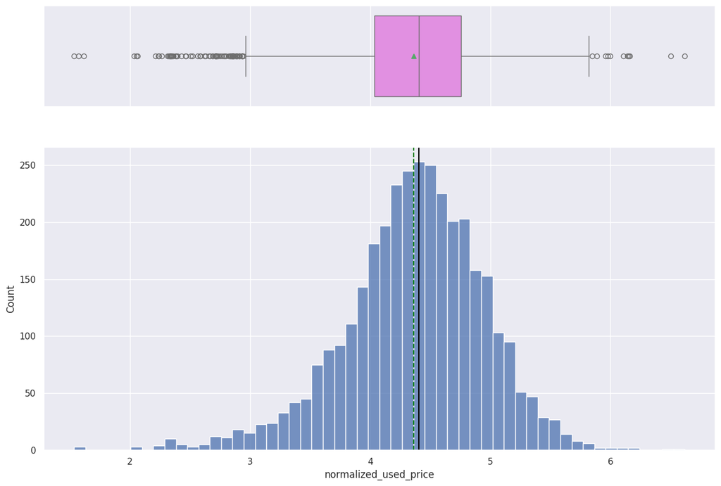

```python
#Checking distribution of normalized used car
histogram_boxplot(df1, "normalized_used_price")
```

#### Observations:

- There are few outlier present in normalized used  
  price.
- The devices used_price seems to have a fairly normal distribution with the min. is around 1.5 euro and mean is around 4 euros.
- the maximum used device price is around 6.5 euros.

## **2.** What percentage of the used device market is dominated by Android devices?

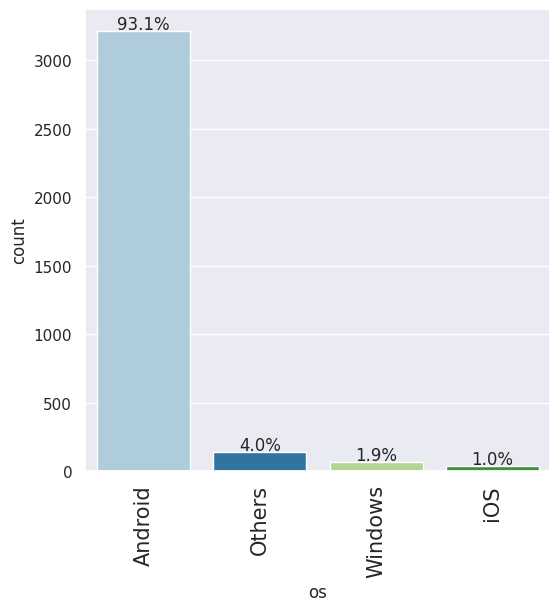

```python
#visualizing percentage of the used device market is dominated by Android devices
labeled_barplot(df1, "os", perc=True)
```

#### Observations:

- 93.1% used device has Android operating system.
- 1% used device has ios operating system.

## **3.** The amount of RAM is important for the smooth functioning of a device. How does the amount of RAM vary with the brand?

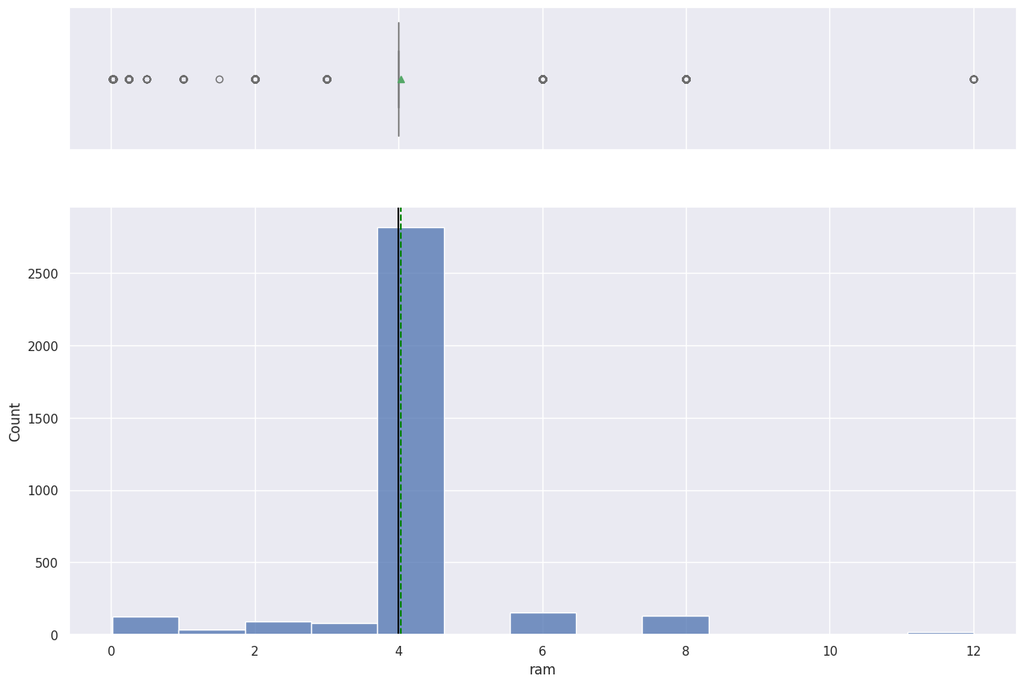

```python
# Let's first explore the data distrubution by boxplot and a histogram for RAM memory
histogram_boxplot(df1, "ram")
```

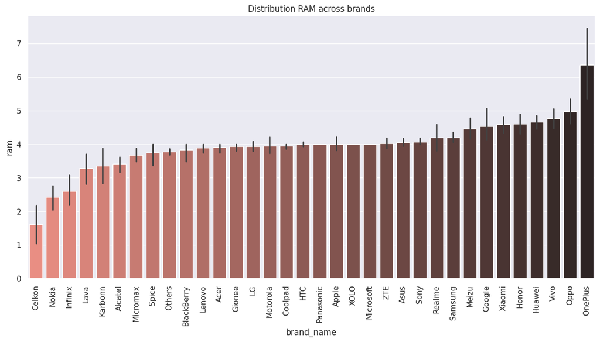

```python
# now let's see the distribution of the ram size across the brands.
order = df1.groupby(["brand_name"])["ram"].mean().sort_values().index #this is for sort data
plt.figure(figsize=(15, 7)) #make figure area
plt.title("Distribution RAM across brands") #add title to the plot
sns.barplot(data=df, x="brand_name", y="ram", order=order,
 palette = "dark:salmon_r") #plotting using our sort index
plt.xticks(rotation=90)
plt.show()
```

## **4.** A large battery often increases a device's weight, making it feel uncomfortable in the hands. How does the weight vary for phones and tablets offering large batteries (more than 4500 mAh)?

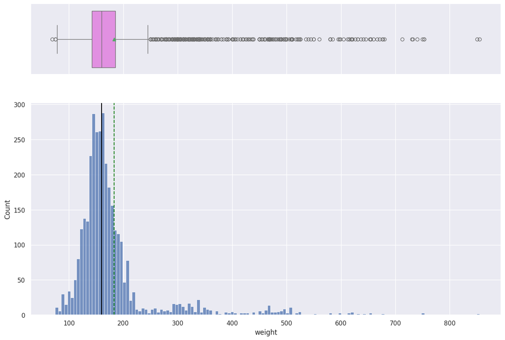

```python
# Let's first explore the data distrubution by boxplot and a histogram for weight
histogram_boxplot(df1, "weight")
plt.show()
```

```python
# Now let's get the weight for batteries larger than 4500 mAh.
df_big_bat = df1[df1.battery > 4500] # create a new dataset called df_big_bat
print(df_big_bat.shape) #checking size of our new dataset
#now let's group by brands and extract the mean of the weight
df_big_bat.groupby("brand_name")["weight"].mean().sort_values(ascending=False)
```

```
(341, 15)
```

```
brand_name
Google       517.000000
Lenovo       442.721429
Apple        439.558824
Sony         439.500000
HTC          425.000000
Samsung      398.352000
Huawei       394.486486
Others       390.546341
Alcatel      380.000000
LG           366.058333
Acer         360.000000
Nokia        318.000000
Asus         313.772727
Honor        248.714286
Xiaomi       231.500000
Gionee       209.430000
Motorola     200.757143
Realme       196.833333
Vivo         195.630769
ZTE          195.400000
Oppo         195.000000
Infinix      193.000000
Panasonic    182.000000
Spice        158.000000
Micromax     118.000000
Name: weight, dtype: float64
```

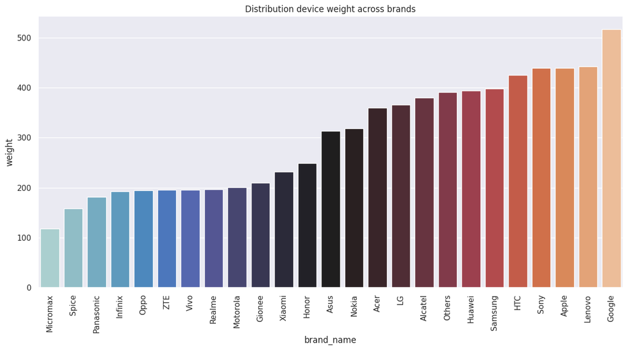

```python
# now let's see the distribution of the weight across across the brands.
orderb = df_big_bat.groupby(["brand_name"])["weight"].mean().sort_values().index #this is for sort the data
plt.figure(figsize=(15, 7)) #make figure area
plt.title("Distribution device weight across brands") #add title to the plot
sns.barplot(data=df_big_bat, x="brand_name", y="weight", order=orderb, ci=None,
 palette = "icefire" ) #plotting using our sort index
plt.xticks(rotation=90)
plt.show()
```

## **5.** Bigger screens are desirable for entertainment purposes as they offer a better viewing experience. How many phones and tablets are available across different brands with a screen size larger than 6 inches?

```python
# Now let's get the devices that have screen size bigger than 6 inches. Because in the data description
#the screen is listed in cm, we need to transforme the values to inches. We do this by multiply the
#values in the column by 2.54 since 1 in = 2.54 cm
df1["screen_size_in"] = df1["screen_size"] / 2.54  #create a new colum with the screen size in inches
df_big_screen = df1[df1.screen_size_in > 6] # create a new dataset called df_big_bat
df_big_screen.shape # geeting size of the datasey
```

```
(1099, 16)
```

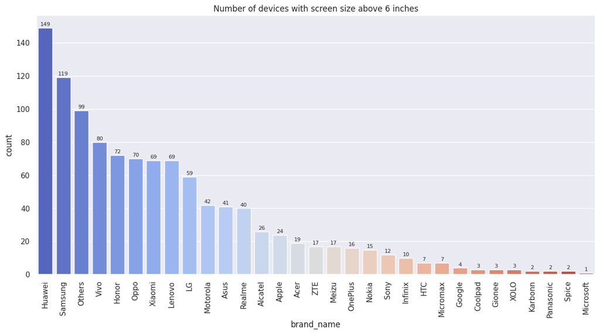

```python
#function creat countolot
def my_labels(ax, feature):
    total = len(feature)
    for p in ax.patches:
        label = format(p.get_height(), '.0f')  # count of each level of the category
        x = p.get_x() + p.get_width() / 2  # width of the plot
        y = p.get_height()  # height of the plot
        ax.annotate(
            label,
            (x, y),
            ha="center",
            va="center",
            size=8,
            xytext=(0, 5),
            textcoords="offset points",
        )  # annotate the count

# Make sure to set the figure size before creating the axes
plt.figure(figsize=(15, 7))

plt.title("Number of devices with screen size above 6 inches")  # add title to the plot

ax1 = sns.countplot(
    data=df_big_screen,
    x="brand_name",
    palette="coolwarm",
    order=df_big_screen["brand_name"].value_counts(ascending=False).index
)  # make a countplot

my_labels(ax1, df_big_screen["brand_name"])  # add values on top of the plot
plt.xticks(rotation=90)  # rotation of the x labels
plt.show()
```

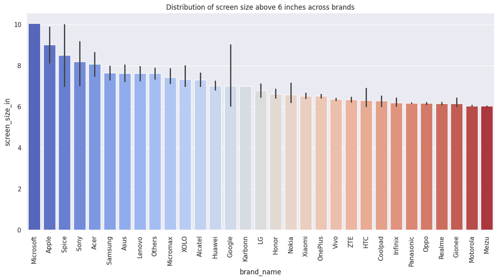

```python
#creating countplot for screen size and brand
orderS = df_big_screen.groupby(["brand_name"])["screen_size_in"].mean().sort_values(ascending=False).index

plt.figure(figsize=(15, 7))
plt.title("Distribution of screen size above 6 inches across brands")

sns.barplot(
    data=df_big_screen,
    x="brand_name",
    y="screen_size_in",
    palette="coolwarm",
    order=orderS
)

plt.xticks(rotation=90)
plt.show()
```

### 6. A lot of devices nowadays offer great selfie cameras, allowing us to capture our favorite moments with loved ones. What is the distribution of devices offering greater than 8MP selfie cameras across brands?

```python
#filtering device has 8 mp_camera
df_selfie_camera = df1[df1.selfie_camera_mp > 8]
#checking shape
df_selfie_camera.shape
```

```
(655, 16)
```

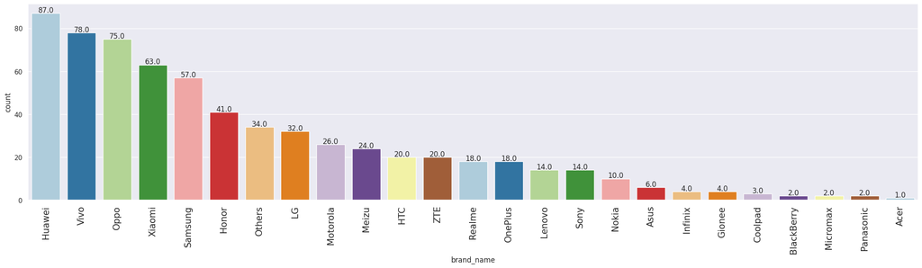

```python
#visuallyizing devices according to 8mp camera
labeled_barplot(df_selfie_camera,'brand_name')
```

## **7.** Which attributes are highly correlated with the price of a used device?

```python
#creating numerical dataframe for checking corelation
df_corr = df1.drop(["brand_name","4g", "5g", "os", "screen_size"],axis=1)
df_corr.head()
```

|  | main_camera_mp | selfie_camera_mp | int_memory | ram | battery | weight | release_year | days_used | normalized_used_price | normalized_new_price | screen_size_in |
| --- | --- | --- | --- | --- | --- | --- | --- | --- | --- | --- | --- |
| 0 | 13.0 | 5.0 | 64.0 | 3.0 | 3020.0 | 146.0 | 2020 | 127 | 4.307572 | 4.715100 | 5.708661 |
| 1 | 13.0 | 16.0 | 128.0 | 8.0 | 4300.0 | 213.0 | 2020 | 325 | 5.162097 | 5.519018 | 6.811024 |
| 2 | 13.0 | 8.0 | 128.0 | 8.0 | 4200.0 | 213.0 | 2020 | 162 | 5.111084 | 5.884631 | 6.570866 |
| 3 | 13.0 | 8.0 | 64.0 | 6.0 | 7250.0 | 480.0 | 2020 | 345 | 5.135387 | 5.630961 | 10.039370 |
| 4 | 13.0 | 8.0 | 64.0 | 3.0 | 5000.0 | 185.0 | 2020 | 293 | 4.389995 | 4.947837 | 6.031496 |

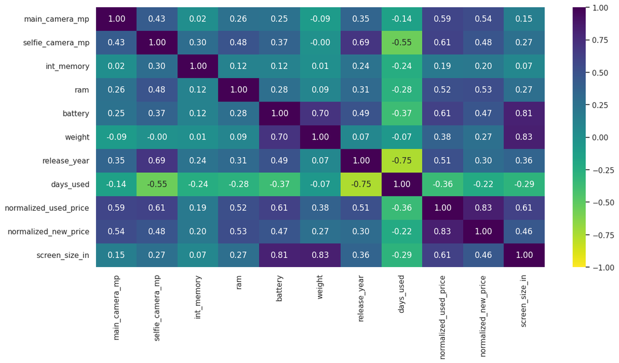

```python
# Now let's plot the correlation coefficients as a heatmap
plt.figure(figsize=(15, 7))
sns.heatmap(df_corr.corr(), annot=True, vmin=-1, vmax=1, fmt=".2f",
 cmap="viridis_r")
```

## Data Preprocessing

- Missing value treatment
- Feature engineering (if needed)
- Outlier detection and treatment (if needed)
- Preparing data for modeling
- Any other preprocessing steps (if needed)

### Missing Value Treatment

```python
# we first create a copy of the data to avoid changes to it
df2 = df1.copy()
```

```python
#let's check for missing values
df2.isnull().sum()
```

```
brand_name                 0
os                         0
screen_size                0
4g                         0
5g                         0
main_camera_mp           179
selfie_camera_mp           2
int_memory                 4
ram                        4
battery                    6
weight                     7
release_year               0
days_used                  0
normalized_used_price      0
normalized_new_price       0
screen_size_in             0
dtype: int64
```

```python
#imputing the missing values
df2[["screen_size","main_camera_mp","selfie_camera_mp"]] = df2.groupby(["brand_name"])[["screen_size","main_camera_mp","selfie_camera_mp"]].transform(lambda x: x.fillna(x.median()))
df2[["int_memory", "ram", "battery", "weight"]] = df2.groupby(["brand_name"])[["int_memory", "ram", "battery", "weight"]].transform(lambda x: x.fillna(x.median()))
df2.isnull().sum()
```

```
brand_name                0
os                        0
screen_size               0
4g                        0
5g                        0
main_camera_mp           10
selfie_camera_mp          0
int_memory                0
ram                       0
battery                   0
weight                    0
release_year              0
days_used                 0
normalized_used_price     0
normalized_new_price      0
screen_size_in            0
dtype: int64
```

```python
#checking those 10 missing vaulues
df2[df2.isnull().any(axis=1)]
df2.isnull().sum()
```

```
brand_name                0
os                        0
screen_size               0
4g                        0
5g                        0
main_camera_mp           10
selfie_camera_mp          0
int_memory                0
ram                       0
battery                   0
weight                    0
release_year              0
days_used                 0
normalized_used_price     0
normalized_new_price      0
screen_size_in            0
dtype: int64
```

```python
#checkingthe missing values
df2[df2.isnull().any(axis=1)]
```

|  | brand_name | os | screen_size | 4g | 5g | main_camera_mp | selfie_camera_mp | int_memory | ram | battery | weight | release_year | days_used | normalized_used_price | normalized_new_price | screen_size_in |
| --- | --- | --- | --- | --- | --- | --- | --- | --- | --- | --- | --- | --- | --- | --- | --- | --- |
| 59 | Infinix | Android | 17.32 | yes | no | NaN | 8.0 | 32.0 | 2.0 | 6000.0 | 209.0 | 2020 | 245 | 4.282068 | 4.597642 | 6.818898 |
| 60 | Infinix | Android | 15.39 | yes | no | NaN | 8.0 | 64.0 | 4.0 | 5000.0 | 185.0 | 2020 | 173 | 4.363608 | 4.711780 | 6.059055 |
| 61 | Infinix | Android | 15.39 | yes | no | NaN | 8.0 | 32.0 | 2.0 | 5000.0 | 185.0 | 2020 | 256 | 4.181439 | 4.505460 | 6.059055 |
| 62 | Infinix | Android | 15.39 | yes | no | NaN | 16.0 | 32.0 | 3.0 | 4000.0 | 178.0 | 2019 | 316 | 4.555244 | 4.602166 | 6.059055 |
| 63 | Infinix | Android | 15.29 | yes | no | NaN | 16.0 | 32.0 | 2.0 | 4000.0 | 165.0 | 2019 | 468 | 4.416670 | 4.871297 | 6.019685 |
| 278 | Infinix | Android | 17.32 | yes | no | NaN | 8.0 | 32.0 | 2.0 | 6000.0 | 209.0 | 2020 | 320 | 4.405133 | 4.605370 | 6.818898 |
| 279 | Infinix | Android | 15.39 | yes | no | NaN | 8.0 | 64.0 | 4.0 | 5000.0 | 185.0 | 2020 | 173 | 4.495913 | 4.702115 | 6.059055 |
| 280 | Infinix | Android | 15.39 | yes | no | NaN | 8.0 | 32.0 | 2.0 | 5000.0 | 185.0 | 2020 | 329 | 4.370713 | 4.487287 | 6.059055 |
| 281 | Infinix | Android | 15.39 | yes | no | NaN | 16.0 | 32.0 | 3.0 | 4000.0 | 178.0 | 2019 | 356 | 4.417997 | 4.605970 | 6.059055 |
| 282 | Infinix | Android | 15.29 | yes | no | NaN | 16.0 | 32.0 | 2.0 | 4000.0 | 165.0 | 2019 | 497 | 4.423289 | 4.866072 | 6.019685 |

#### Observations:

• Because all the missing values are from the same brand (Infinix), I'll drop them assuming there is no enought data

```python
#Let's drop the Nan
df2.dropna(subset=["main_camera_mp"], inplace=True)
df2.isnull().sum()
```

```
brand_name               0
os                       0
screen_size              0
4g                       0
5g                       0
main_camera_mp           0
selfie_camera_mp         0
int_memory               0
ram                      0
battery                  0
weight                   0
release_year             0
days_used                0
normalized_used_price    0
normalized_new_price     0
screen_size_in           0
dtype: int64
```

```python
#creating a new dataframe with numerical colums only
num_df = df2.drop(["brand_name","4g", "5g", "os"],axis=1)
num_df.head()
```

|  | screen_size | main_camera_mp | selfie_camera_mp | int_memory | ram | battery | weight | release_year | days_used | normalized_used_price | normalized_new_price | screen_size_in |
| --- | --- | --- | --- | --- | --- | --- | --- | --- | --- | --- | --- | --- |
| 0 | 14.50 | 13.0 | 5.0 | 64.0 | 3.0 | 3020.0 | 146.0 | 2020 | 127 | 4.307572 | 4.715100 | 5.708661 |
| 1 | 17.30 | 13.0 | 16.0 | 128.0 | 8.0 | 4300.0 | 213.0 | 2020 | 325 | 5.162097 | 5.519018 | 6.811024 |
| 2 | 16.69 | 13.0 | 8.0 | 128.0 | 8.0 | 4200.0 | 213.0 | 2020 | 162 | 5.111084 | 5.884631 | 6.570866 |
| 3 | 25.50 | 13.0 | 8.0 | 64.0 | 6.0 | 7250.0 | 480.0 | 2020 | 345 | 5.135387 | 5.630961 | 10.039370 |
| 4 | 15.32 | 13.0 | 8.0 | 64.0 | 3.0 | 5000.0 | 185.0 | 2020 | 293 | 4.389995 | 4.947837 | 6.031496 |

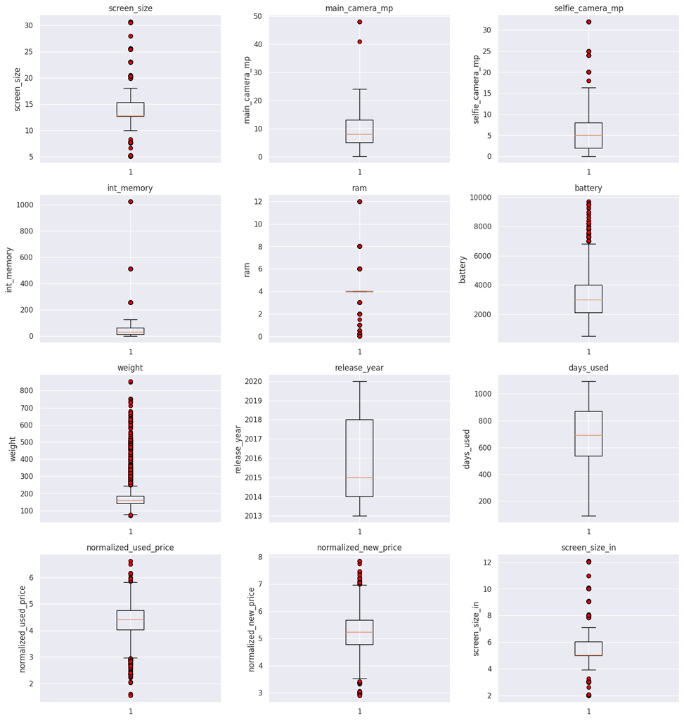

```python
plt.figure(figsize=(15, 35))  # figure area size
red_dot = dict(markerfacecolor="red", marker="o")  # to make the outliers in red dots using flierprops

for i, variable in enumerate(num_df.columns):
    plt.subplot(9, 3, i + 1)

    # Convert the column to numeric (if needed)
    num_df[variable] = pd.to_numeric(num_df[variable], errors='coerce')

    # Drop NaN or missing values
    num_df_cleaned = num_df[variable].dropna()

    plt.boxplot(num_df_cleaned, whis=1.5, flierprops=red_dot)  # adjust whis if needed
    plt.title(variable)
    plt.ylabel(variable)  # add y-axis label for better readability
    plt.tight_layout()

plt.show()
```

**• All colums do have outliers in them excepted for days_used and released_year. Note: We will not treat outliers in the this dataset.**

```python
#treating release_year and days_used
def treat_outliers(df, col):
 """
 Treats outliers in a variable
 df: dataframe
 col: dataframe column
 """
 Q1 = df[col].quantile(0.25) # 25th quantile
 Q3 = df[col].quantile(0.75) # 75th quantile
 IQR = Q3 - Q1
 Lower_Whisker = Q1 - 1.5 * IQR
 Upper_Whisker = Q3 + 1.5 * IQR
 # all the values smaller than Lower_Whisker will be assigned the value of Lower_Whisker
 # all the values greater than Upper_Whisker will be assigned the value of Upper_Whisker
 df[col] = np.clip(df[col], Lower_Whisker, Upper_Whisker)
 return df
def treat_outliers_all(df, col_list):
 """
 Treat outliers in a list of variables
 df: dataframe
 col_list: list of dataframe columns
 """
 for c in col_list:
  df = treat_outliers(df, c)
 return df
```

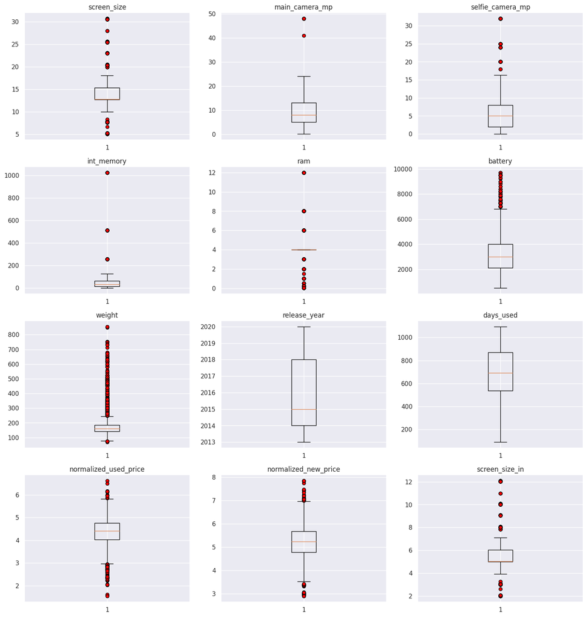

```python
#creating boxplots for each colum in its own scale
plt.figure(figsize=(15, 35)) #figure area size
red_dot = dict(markerfacecolor = "red", marker= "o") #to make the outliers in red dots using flierprops
for i, variable in enumerate(num_df):
 plt.subplot(9, 3, i + 1)
 plt.boxplot(num_df[variable], whis=1.5, flierprops= red_dot)#whis = 1.5 correspondsto Tukey's original definition of boxplots.
 plt.tight_layout()
 plt.title(variable)

plt.show()
```

## EDA

- It is a good idea to explore the data once again after manipulating it.

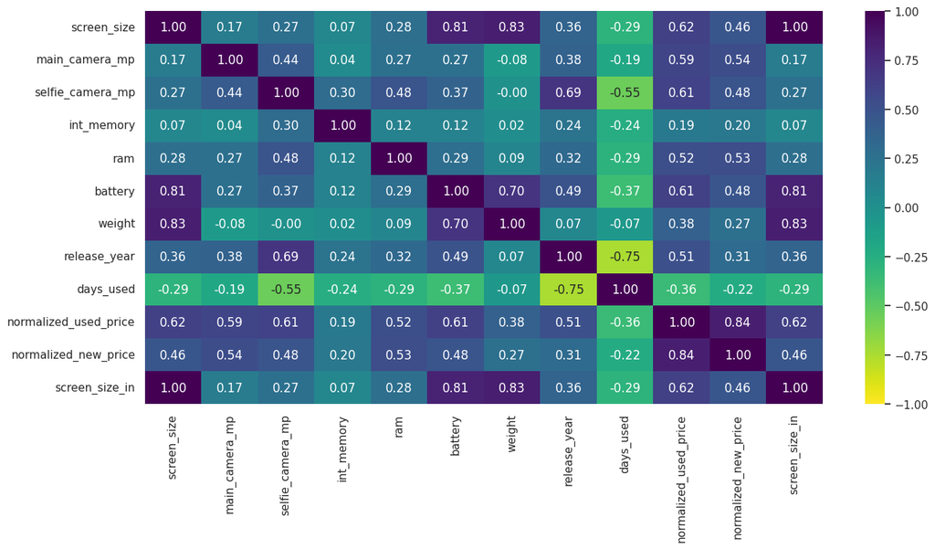

```python
# Now let's plot the correlation coefficients as a heatmap AFTER NAs treatment (num_df)
plt.figure(figsize=(15, 7))
sns.heatmap(num_df.corr(), annot=True, vmin=-1, vmax=1, fmt=".2f",
 cmap="viridis_r")
plt.show()
```

#### Observations:

- there are strong coorelation between battery,weight and screen size.
- there are negative correlation between release_year and day_used.
- there are strong correlation between normalized_used_price and normalized_new_price.

## Model Building - Linear Regression

```python
#checking numerical column
df2.columns
```

```
Index(['brand_name', 'os', 'screen_size', '4g', '5g', 'main_camera_mp',
       'selfie_camera_mp', 'int_memory', 'ram', 'battery', 'weight',
       'release_year', 'days_used', 'normalized_used_price',
       'normalized_new_price', 'screen_size_in'],
      dtype='object')
```

```python
#checking the numerical df shape
df2.shape
```

```
(3444, 16)
```

```python
#droping extra column
df2.drop("screen_size_in",axis=1,inplace=True)
```

```python
# Let's first define our X and y variables
X =df2.drop(["normalized_used_price"], axis=1)## these are independent variables
y = df2["normalized_used_price"] #we are going to use the log transformed price for the dependent variable
```

```python
#displaying x and y
print(X.head())
print("*"*50)
print(y.head())
```

```
  brand_name       os  screen_size   4g   5g  main_camera_mp  \
0      Honor  Android        14.50  yes   no            13.0
1      Honor  Android        17.30  yes  yes            13.0
2      Honor  Android        16.69  yes  yes            13.0
3      Honor  Android        25.50  yes  yes            13.0
4      Honor  Android        15.32  yes   no            13.0

   selfie_camera_mp  int_memory  ram  battery  weight  release_year  \
0               5.0        64.0  3.0   3020.0   146.0          2020
1              16.0       128.0  8.0   4300.0   213.0          2020
2               8.0       128.0  8.0   4200.0   213.0          2020
3               8.0        64.0  6.0   7250.0   480.0          2020
4               8.0        64.0  3.0   5000.0   185.0          2020

   days_used  normalized_new_price
0        127              4.715100
1        325              5.519018
2        162              5.884631
3        345              5.630961
4        293              4.947837
0    4.307572
1    5.162097
2    5.111084
3    5.135387
4    4.389995
Name: normalized_used_price, dtype: float64
```

```python
# creating dummy variable of object or text column
X = pd.get_dummies(
 X,
 columns=X.select_dtypes(include=["object", "category"]).columns.tolist(),
 drop_first=True,
)
X.head()
```

|  | screen_size | main_camera_mp | selfie_camera_mp | int_memory | ram | battery | weight | release_year | days_used | normalized_new_price | ... | brand_name_Spice | brand_name_Vivo | brand_name_XOLO | brand_name_Xiaomi | brand_name_ZTE | os_Others | os_Windows | os_iOS | 4g_yes | 5g_yes |
| --- | --- | --- | --- | --- | --- | --- | --- | --- | --- | --- | --- | --- | --- | --- | --- | --- | --- | --- | --- | --- | --- |
| 0 | 14.50 | 13.0 | 5.0 | 64.0 | 3.0 | 3020.0 | 146.0 | 2020 | 127 | 4.715100 | ... | 0 | 0 | 0 | 0 | 0 | 0 | 0 | 0 | 1 | 0 |
| 1 | 17.30 | 13.0 | 16.0 | 128.0 | 8.0 | 4300.0 | 213.0 | 2020 | 325 | 5.519018 | ... | 0 | 0 | 0 | 0 | 0 | 0 | 0 | 0 | 1 | 1 |
| 2 | 16.69 | 13.0 | 8.0 | 128.0 | 8.0 | 4200.0 | 213.0 | 2020 | 162 | 5.884631 | ... | 0 | 0 | 0 | 0 | 0 | 0 | 0 | 0 | 1 | 1 |
| 3 | 25.50 | 13.0 | 8.0 | 64.0 | 6.0 | 7250.0 | 480.0 | 2020 | 345 | 5.630961 | ... | 0 | 0 | 0 | 0 | 0 | 0 | 0 | 0 | 1 | 1 |
| 4 | 15.32 | 13.0 | 8.0 | 64.0 | 3.0 | 5000.0 | 185.0 | 2020 | 293 | 4.947837 | ... | 0 | 0 | 0 | 0 | 0 | 0 | 0 | 0 | 1 | 0 |

5 rows × 47 columns

```python
#checking the shape after creating dummy variable
X.shape
```

```
(3444, 47)
```

```python
# let's add the intercept to data
X = sm.add_constant(X)
```

## Splitting dataset

```python
# Let's split the data in 70:30 ratio to use a training data
x_train, x_test, y_train, y_test = train_test_split(X, y, test_size=0.3,
random_state=1)
```

```python
# and now lets see how many values in each data set
print("Number of rows in training data =", x_train.shape[0])
print("Number of rows in test data =", x_test.shape[0])
```

```
Number of rows in training data = 2410
Number of rows in test data = 1034
```

## Building model

```python
#ols model for training data set
olsmodel = sm.OLS(y_train, x_train).fit()
print(olsmodel.summary())
```

```
                              OLS Regression Results
=================================================================================
Dep. Variable:     normalized_used_price   R-squared:                       0.846
Model:                               OLS   Adj. R-squared:                  0.843
Method:                    Least Squares   F-statistic:                     275.8
Date:                   Wed, 31 Jan 2024   Prob (F-statistic):               0.00
Time:                           17:17:42   Log-Likelihood:                 80.997
No. Observations:                   2410   AIC:                            -65.99
Df Residuals:                       2362   BIC:                             211.8
Df Model:                             47
Covariance Type:               nonrobust
=========================================================================================
                            coef    std err          t      P>|t|      [0.025      0.975]
-----------------------------------------------------------------------------------------
const                   -49.9858      9.193     -5.437      0.000     -68.013     -31.959
screen_size               0.0266      0.004      7.552      0.000       0.020       0.033
main_camera_mp            0.0204      0.002     13.166      0.000       0.017       0.023
selfie_camera_mp          0.0129      0.001     11.016      0.000       0.011       0.015
int_memory             6.158e-06    7.1e-05      0.087      0.931      -0.000       0.000
ram                       0.0236      0.005      4.474      0.000       0.013       0.034
battery               -2.598e-05   7.94e-06     -3.272      0.001   -4.16e-05   -1.04e-05
weight                    0.0010      0.000      7.493      0.000       0.001       0.001
release_year              0.0254      0.005      5.570      0.000       0.016       0.034
days_used              1.168e-05   3.08e-05      0.379      0.705   -4.88e-05    7.21e-05
normalized_new_price      0.4421      0.012     35.991      0.000       0.418       0.466
brand_name_Alcatel        0.0073      0.048      0.154      0.878      -0.086       0.101
brand_name_Apple         -0.0116      0.149     -0.078      0.938      -0.304       0.281
brand_name_Asus           0.0272      0.047      0.575      0.565      -0.066       0.120
brand_name_BlackBerry     0.1219      0.074      1.652      0.099      -0.023       0.267
brand_name_Celkon        -0.0653      0.070     -0.929      0.353      -0.203       0.072
brand_name_Coolpad        0.0343      0.070      0.488      0.626      -0.103       0.172
brand_name_Gionee         0.0255      0.056      0.452      0.651      -0.085       0.136
brand_name_Google         0.0390      0.105      0.372      0.710      -0.167       0.245
brand_name_HTC           -0.0002      0.048     -0.005      0.996      -0.095       0.095
brand_name_Honor          0.0233      0.049      0.476      0.634      -0.073       0.119
brand_name_Huawei         0.0075      0.044      0.170      0.865      -0.079       0.094
brand_name_Karbonn        0.0225      0.065      0.348      0.728      -0.105       0.150
brand_name_LG            -0.0049      0.045     -0.110      0.913      -0.092       0.083
brand_name_Lava           0.0752      0.065      1.160      0.246      -0.052       0.202
brand_name_Lenovo         0.0333      0.045      0.742      0.458      -0.055       0.121
```

[output cut: 18 more lines]

```
os_Windows                0.0428      0.044      0.982      0.326      -0.043       0.128
os_iOS                   -0.0826      0.149     -0.554      0.579      -0.375       0.210
4g_yes                    0.0609      0.016      3.776      0.000       0.029       0.093
5g_yes                   -0.0624      0.031     -1.990      0.047      -0.124      -0.001
==============================================================================
Omnibus:                      263.845   Durbin-Watson:                   1.988
Prob(Omnibus):                  0.000   Jarque-Bera (JB):              657.789
Skew:                          -0.625   Prob(JB):                    1.45e-143
Kurtosis:                       5.233   Cond. No.                     7.53e+06
==============================================================================

Notes:
[1] Standard Errors assume that the covariance matrix of the errors is correctly specified.
[2] The condition number is large, 7.53e+06. This might indicate that there are
strong multicollinearity or other numerical problems.
```

#### Observations:

• the value for adj. R-squared is **0.843**, which is good.

• the value for const coefficient is **-49.985**

## Model Performance Check

```python
# function to compute adjusted R-squared
def adj_r2_score(predictors, targets, predictions):
 r2 = r2_score(targets, predictions)
 n = predictors.shape[0]
 k = predictors.shape[1]
 return 1 - ((1 - r2) * (n - 1) / (n - k - 1))
# function to compute MAPE
def mape_score(targets, predictions):
 return np.mean(np.abs(targets - predictions) / targets) * 100
# function to compute different metrics to check performance of a regression model
def model_performance_regression(model, predictors, target):
 """
 Function to compute different metrics to check regression model performance
 model: regressor
 predictors: independent variables
 target: dependent variable
 """
 # predicting using the independent variables
 pred = model.predict(predictors)
 r2 = r2_score(target, pred) # to compute R-squared
 adjr2 = adj_r2_score(predictors, target, pred) # to compute adjusted R-squared
 rmse = np.sqrt(mean_squared_error(target, pred)) # to compute RMSE
 mae = mean_absolute_error(target, pred) # to compute MAE
 mape = mape_score(target, pred) # to compute MAPE
 # creating a dataframe of metrics
 df_perf = pd.DataFrame(
 {
 "RMSE": rmse,
 "MAE": mae,
 "R-squared": r2,
 "Adj. R-squared": adjr2,
 "MAPE": mape,
 },
 index=[0],
 )
 return df_perf
```

```python
# Now let's check model performance on train set
print("Training Performance\n")
olsmodel_tr_perf = model_performance_regression(olsmodel, x_train, y_train)
print("Training Performance")
olsmodel_tr_perf
```

```
Training Performance

Training Performance
```

|  | RMSE | MAE | R-squared | Adj. R-squared | MAPE |
| --- | --- | --- | --- | --- | --- |
| 0 | 0.233974 | 0.181465 | 0.845867 | 0.842734 | 4.380732 |

```python
# checking model performance on test set (seen 30% data)
print("Test Performance\n")
olsmodel_test_perf = model_performance_regression(olsmodel, x_test, y_test)
print("Test Performance")
olsmodel_test_perf
```

```
Test Performance

Test Performance
```

|  | RMSE | MAE | R-squared | Adj. R-squared | MAPE |
| --- | --- | --- | --- | --- | --- |
| 0 | 0.229577 | 0.179787 | 0.840412 | 0.832635 | 4.270302 |

#### Observations:

• The training $R^2$ is 0.84, so the model is not underfitting.

• The train and test RMSE and MAE are comparable, also indicating that the model is not overfitting.

• MAPE means that we are able to predict within 4.3% of the used price.

## Checking Linear Regression Assumptions

- In order to make statistical inferences from a linear regression model, it is important to ensure that the assumptions of linear regression are satisfied.

#### 1. Multicollinearity

```python
# importing variance_inflation_factor
from statsmodels.stats.outliers_influence import variance_inflation_factor


def checking_vif(predictors):
    vif = pd.DataFrame()
    vif["feature"] = predictors.columns

    # calculating VIF for each feature
    vif["VIF"] = [
        variance_inflation_factor(predictors.values, i)
        for i in range(len(predictors.columns))
    ]
    return vif
```

```python
#checking vif into train data
checking_vif(x_train)
```

|  | feature | VIF |
| --- | --- | --- |
| 0 | const | 3.646388e+06 |
| 1 | screen_size | 7.729621e+00 |
| 2 | main_camera_mp | 2.330059e+00 |
| 3 | selfie_camera_mp | 2.891093e+00 |
| 4 | int_memory | 1.372100e+00 |
| 5 | ram | 2.270635e+00 |
| 6 | battery | 4.610533e+00 |
| 7 | weight | 6.089586e+00 |
| 8 | release_year | 4.700433e+00 |
| 9 | days_used | 2.559045e+00 |
| 10 | normalized_new_price | 3.118523e+00 |
| 11 | brand_name_Alcatel | 3.251978e+00 |
| 12 | brand_name_Apple | 1.293249e+01 |
| 13 | brand_name_Asus | 3.283658e+00 |
| 14 | brand_name_BlackBerry | 1.548662e+00 |
| 15 | brand_name_Celkon | 1.665582e+00 |
| 16 | brand_name_Coolpad | 1.490756e+00 |
| 17 | brand_name_Gionee | 1.970378e+00 |
| 18 | brand_name_Google | 1.177118e+00 |
| 19 | brand_name_HTC | 3.082566e+00 |
| 20 | brand_name_Honor | 3.200004e+00 |
| 21 | brand_name_Huawei | 5.632981e+00 |
| 22 | brand_name_Karbonn | 1.638957e+00 |
| 23 | brand_name_LG | 4.768771e+00 |
| 24 | brand_name_Lava | 1.640449e+00 |
| 25 | brand_name_Lenovo | 4.339403e+00 |
| 26 | brand_name_Meizu | 2.237106e+00 |
| 27 | brand_name_Micromax | 3.240485e+00 |
| 28 | brand_name_Microsoft | 1.895489e+00 |
| 29 | brand_name_Motorola | 3.104999e+00 |
| 30 | brand_name_Nokia | 3.430216e+00 |
| 31 | brand_name_OnePlus | 1.464815e+00 |
| 32 | brand_name_Oppo | 3.600707e+00 |
| 33 | brand_name_Others | 9.295538e+00 |
| 34 | brand_name_Panasonic | 2.088837e+00 |
| 35 | brand_name_Realme | 1.822635e+00 |
| 36 | brand_name_Samsung | 7.017418e+00 |
| 37 | brand_name_Sony | 2.671856e+00 |
| 38 | brand_name_Spice | 1.542670e+00 |
| 39 | brand_name_Vivo | 3.367327e+00 |
| 40 | brand_name_XOLO | 1.944538e+00 |
| 41 | brand_name_Xiaomi | 3.633755e+00 |
| 42 | brand_name_ZTE | 3.723375e+00 |
| 43 | os_Others | 1.778992e+00 |
| 44 | os_Windows | 1.664275e+00 |
| 45 | os_iOS | 1.179209e+01 |
| 46 | 4g_yes | 2.454847e+00 |
| 47 | 5g_yes | 1.863663e+00 |

#### Observations:

• weight,screen_size predictors have VIF score greater than 5 and therefore we drop multicollinearity.

• We will ignore the VIF values for dummy variables and the constant (intercept)

### Removing Multicollinearity

```python
#treating multicollinearity
def treating_multicollinearity(predictors, target, high_vif_columns):
    """
    Checking the effect of dropping the columns showing high multicollinearity
    on model performance (adj. R-squared and RMSE)

    predictors: independent variables
    target: dependent variable
    high_vif_columns: columns having high VIF
    """
    # empty lists to store adj. R-squared and RMSE values
    adj_r2 = []
    rmse = []

    # build ols models by dropping one of the high VIF columns at a time
    # store the adjusted R-squared and RMSE in the lists defined previously
    for cols in high_vif_columns:
        # defining the new train set
        train = predictors.loc[:, ~predictors.columns.str.startswith(cols)]

        # create the model
        olsmodel = sm.OLS(target, train).fit()

        # adding adj. R-squared and RMSE to the lists
        adj_r2.append(olsmodel.rsquared_adj)
        rmse.append(np.sqrt(olsmodel.mse_resid))

    # creating a dataframe for the results
    temp = pd.DataFrame(
        {
            "col": high_vif_columns,
            "Adj. R-squared after_dropping col": adj_r2,
            "RMSE after dropping col": rmse,
        }
    ).sort_values(by="Adj. R-squared after_dropping col", ascending=False)
    temp.reset_index(drop=True, inplace=True)

    return temp
```

```python
#treating multicolarity to screen_size
col_list = ["screen_size"]
res = treating_multicollinearity(x_train, y_train, col_list)
res
```

|  | col | Adj. R-squared after_dropping col | RMSE after dropping col |
| --- | --- | --- | --- |
| 0 | screen_size | 0.839072 | 0.239125 |

```python
#droping screen size because of multocollarearity
col_to_drop = "screen_size"
x_train2 = x_train.loc[:, ~x_train.columns.str.startswith(col_to_drop)]
x_test2 = x_test.loc[:, ~x_test.columns.str.startswith(col_to_drop)]

# Check VIF now
vif = checking_vif(x_train2)
print("VIF after dropping ", col_to_drop)
vif
```

```
VIF after dropping  screen_size
```

|  | feature | VIF |
| --- | --- | --- |
| 0 | const | 3.548867e+06 |
| 1 | main_camera_mp | 2.326224e+00 |
| 2 | selfie_camera_mp | 2.887472e+00 |
| 3 | int_memory | 1.366984e+00 |
| 4 | ram | 2.269597e+00 |
| 5 | battery | 4.153608e+00 |
| 6 | weight | 3.206289e+00 |
| 7 | release_year | 4.571144e+00 |
| 8 | days_used | 2.550111e+00 |
| 9 | normalized_new_price | 3.082812e+00 |
| 10 | brand_name_Alcatel | 3.251294e+00 |
| 11 | brand_name_Apple | 1.287411e+01 |
| 12 | brand_name_Asus | 3.277959e+00 |
| 13 | brand_name_BlackBerry | 1.547326e+00 |
| 14 | brand_name_Celkon | 1.664706e+00 |
| 15 | brand_name_Coolpad | 1.489892e+00 |
| 16 | brand_name_Gionee | 1.962885e+00 |
| 17 | brand_name_Google | 1.175997e+00 |
| 18 | brand_name_HTC | 3.076841e+00 |
| 19 | brand_name_Honor | 3.199934e+00 |
| 20 | brand_name_Huawei | 5.630769e+00 |
| 21 | brand_name_Karbonn | 1.638890e+00 |
| 22 | brand_name_LG | 4.755600e+00 |
| 23 | brand_name_Lava | 1.640449e+00 |
| 24 | brand_name_Lenovo | 4.335908e+00 |
| 25 | brand_name_Meizu | 2.234127e+00 |
| 26 | brand_name_Micromax | 3.237207e+00 |
| 27 | brand_name_Microsoft | 1.893375e+00 |
| 28 | brand_name_Motorola | 3.093281e+00 |
| 29 | brand_name_Nokia | 3.419628e+00 |
| 30 | brand_name_OnePlus | 1.464803e+00 |
| 31 | brand_name_Oppo | 3.595105e+00 |
| 32 | brand_name_Others | 9.247623e+00 |
| 33 | brand_name_Panasonic | 2.086830e+00 |
| 34 | brand_name_Realme | 1.819866e+00 |
| 35 | brand_name_Samsung | 7.002531e+00 |
| 36 | brand_name_Sony | 2.666220e+00 |
| 37 | brand_name_Spice | 1.542375e+00 |
| 38 | brand_name_Vivo | 3.367042e+00 |
| 39 | brand_name_XOLO | 1.944233e+00 |
| 40 | brand_name_Xiaomi | 3.627031e+00 |
| 41 | brand_name_ZTE | 3.718113e+00 |
| 42 | os_Others | 1.543702e+00 |
| 43 | os_Windows | 1.664260e+00 |
| 44 | os_iOS | 1.167895e+01 |
| 45 | 4g_yes | 2.451517e+00 |
| 46 | 5g_yes | 1.860337e+00 |

#### observations:

- droped only screen_size and vif of weight is below 5 .
- all variable has no multicolarity except dummy variable.

```python
# fitting the slope and getting its summary
olsmod1 = sm.OLS(y_train, x_train2).fit()
print(olsmod1.summary())
```

```
                              OLS Regression Results
=================================================================================
Dep. Variable:     normalized_used_price   R-squared:                       0.842
Model:                               OLS   Adj. R-squared:                  0.839
Method:                    Least Squares   F-statistic:                     274.1
Date:                   Wed, 31 Jan 2024   Prob (F-statistic):               0.00
Time:                           17:17:43   Log-Likelihood:                 52.246
No. Observations:                   2410   AIC:                            -10.49
Df Residuals:                       2363   BIC:                             261.5
Df Model:                             46
Covariance Type:               nonrobust
=========================================================================================
                            coef    std err          t      P>|t|      [0.025      0.975]
-----------------------------------------------------------------------------------------
const                   -61.3396      9.176     -6.685      0.000     -79.334     -43.345
main_camera_mp            0.0208      0.002     13.326      0.000       0.018       0.024
selfie_camera_mp          0.0132      0.001     11.158      0.000       0.011       0.016
int_memory            -2.658e-05   7.17e-05     -0.371      0.711      -0.000       0.000
ram                       0.0244      0.005      4.583      0.000       0.014       0.035
battery               -7.103e-06   7.63e-06     -0.931      0.352   -2.21e-05    7.85e-06
weight                    0.0017   9.96e-05     17.284      0.000       0.002       0.002
release_year              0.0311      0.005      6.838      0.000       0.022       0.040
days_used             -2.078e-06   3.11e-05     -0.067      0.947   -6.31e-05     5.9e-05
normalized_new_price      0.4521      0.012     36.580      0.000       0.428       0.476
brand_name_Alcatel        0.0125      0.048      0.260      0.795      -0.082       0.107
brand_name_Apple          0.0640      0.150      0.426      0.670      -0.231       0.359
brand_name_Asus           0.0123      0.048      0.257      0.797      -0.081       0.106
brand_name_BlackBerry     0.1055      0.075      1.415      0.157      -0.041       0.252
brand_name_Celkon        -0.0775      0.071     -1.090      0.276      -0.217       0.062
brand_name_Coolpad        0.0215      0.071      0.302      0.762      -0.118       0.161
brand_name_Gionee        -0.0008      0.057     -0.014      0.989      -0.113       0.111
brand_name_Google         0.0146      0.106      0.137      0.891      -0.193       0.222
brand_name_HTC           -0.0160      0.049     -0.327      0.744      -0.112       0.080
brand_name_Honor          0.0251      0.050      0.506      0.613      -0.072       0.122
brand_name_Huawei         0.0009      0.045      0.020      0.984      -0.086       0.088
brand_name_Karbonn        0.0257      0.066      0.391      0.696      -0.103       0.154
brand_name_LG            -0.0226      0.045     -0.501      0.616      -0.111       0.066
brand_name_Lava           0.0752      0.066      1.147      0.252      -0.053       0.204
brand_name_Lenovo         0.0237      0.045      0.522      0.602      -0.065       0.113
brand_name_Meizu         -0.0107      0.055     -0.194      0.846      -0.119       0.097
```

[output cut: 17 more lines]

```
os_Windows                0.0438      0.044      0.993      0.321      -0.043       0.130
os_iOS                   -0.1929      0.150     -1.285      0.199      -0.487       0.101
4g_yes                    0.0564      0.016      3.459      0.001       0.024       0.088
5g_yes                   -0.0724      0.032     -2.284      0.022      -0.135      -0.010
==============================================================================
Omnibus:                      271.538   Durbin-Watson:                   1.992
Prob(Omnibus):                  0.000   Jarque-Bera (JB):              649.120
Skew:                          -0.654   Prob(JB):                    1.11e-141
Kurtosis:                       5.180   Cond. No.                     7.43e+06
==============================================================================

Notes:
[1] Standard Errors assume that the covariance matrix of the errors is correctly specified.
[2] The condition number is large, 7.43e+06. This might indicate that there are
strong multicollinearity or other numerical problems.
```

**there are so many variable has p value is greater then 0.05. we will treat it**

#### Dealing with high p-value variables

• we are going to use the formula beloew to extract the features with significant pvalue only

```python
# initial list of columns
predictors = x_train2.copy()
cols = predictors.columns.tolist()

# setting an initial max p-value
max_p_value = 1

while len(cols) > 0:
    # defining the train set
    x_train_aux = predictors[cols]

    # fitting the model
    model = sm.OLS(y_train, x_train_aux).fit()

    # getting the p-values and the maximum p-value
    p_values = model.pvalues
    max_p_value = max(p_values)

    # name of the variable with maximum p-value
    feature_with_p_max = p_values.idxmax()

    if max_p_value > 0.05:
        cols.remove(feature_with_p_max)
    else:
        break

selected_features = cols
print(selected_features)
```

```
['const', 'main_camera_mp', 'selfie_camera_mp', 'ram', 'weight', 'release_year', 'normalized_new_price', 'brand_name_Sony', 'brand_name_Xiaomi', 'os_Others', 'os_iOS', '4g_yes', '5g_yes']
```

```python
#selecting the column into train and test
x_train3 = x_train2[selected_features]
x_test3 = x_test2[selected_features]
```

```python
#fitting the model and getting summery
olsmod2 = sm.OLS(y_train, x_train3).fit()
print(olsmod2.summary())
```

```
                              OLS Regression Results
=================================================================================
Dep. Variable:     normalized_used_price   R-squared:                       0.840
Model:                               OLS   Adj. R-squared:                  0.840
Method:                    Least Squares   F-statistic:                     1051.
Date:                   Wed, 31 Jan 2024   Prob (F-statistic):               0.00
Time:                           17:17:43   Log-Likelihood:                 38.636
No. Observations:                   2410   AIC:                            -51.27
Df Residuals:                       2397   BIC:                             23.96
Df Model:                             12
Covariance Type:               nonrobust
========================================================================================
                           coef    std err          t      P>|t|      [0.025      0.975]
----------------------------------------------------------------------------------------
const                  -59.4554      6.985     -8.511      0.000     -73.153     -45.757
main_camera_mp           0.0214      0.001     14.706      0.000       0.019       0.024
selfie_camera_mp         0.0129      0.001     11.523      0.000       0.011       0.015
ram                      0.0264      0.005      5.168      0.000       0.016       0.036
weight                   0.0017    6.2e-05     26.778      0.000       0.002       0.002
release_year             0.0301      0.003      8.705      0.000       0.023       0.037
normalized_new_price     0.4450      0.011     39.784      0.000       0.423       0.467
brand_name_Sony         -0.0780      0.032     -2.417      0.016      -0.141      -0.015
brand_name_Xiaomi        0.0767      0.026      2.978      0.003       0.026       0.127
os_Others               -0.1399      0.027     -5.144      0.000      -0.193      -0.087
os_iOS                  -0.1184      0.046     -2.598      0.009      -0.208      -0.029
4g_yes                   0.0545      0.015      3.576      0.000       0.025       0.084
5g_yes                  -0.0680      0.030     -2.244      0.025      -0.127      -0.009
==============================================================================
Omnibus:                      271.684   Durbin-Watson:                   1.998
Prob(Omnibus):                  0.000   Jarque-Bera (JB):              627.943
Skew:                          -0.665   Prob(JB):                    4.40e-137
Kurtosis:                       5.118   Cond. No.                     2.91e+06
==============================================================================

Notes:
[1] Standard Errors assume that the covariance matrix of the errors is correctly specified.
[2] The condition number is large, 2.91e+06. This might indicate that there are
strong multicollinearity or other numerical problems.
```

```python
# checking model performance on train set (seen 70% data)
print("Training Performance\n")
olsmod2_train_perf = model_performance_regression(olsmod2, x_train3, y_train)
olsmod2_train_perf
```

```
Training Performance
```

|  | RMSE | MAE | R-squared | Adj. R-squared | MAPE |
| --- | --- | --- | --- | --- | --- |
| 0 | 0.238123 | 0.184771 | 0.840352 | 0.839486 | 4.473911 |

```python
# checking model performance on test set (seen 30% data)
print("Test Performance\n")
olsmod2_test_perf = model_performance_regression(olsmod2, x_test3, y_test)
olsmod2_test_perf
```

```
Test Performance
```

|  | RMSE | MAE | R-squared | Adj. R-squared | MAPE |
| --- | --- | --- | --- | --- | --- |
| 0 | 0.232409 | 0.18168 | 0.83645 | 0.834365 | 4.330859 |

```python
# let us create a dataframe with actual, fitted and residual values
df_pred = pd.DataFrame()

df_pred["Actual Values"] = y_train  # actual values
df_pred["Fitted Values"] = olsmod2.fittedvalues  # predicted values
df_pred["Residuals"] = olsmod2.resid  # residuals

df_pred.head()
```

|  | Actual Values | Fitted Values | Residuals |
| --- | --- | --- | --- |
| 1397 | 4.034241 | 4.178982 | -0.144741 |
| 2662 | 4.487062 | 4.760471 | -0.273409 |
| 693 | 4.029095 | 4.225284 | -0.196189 |
| 1463 | 4.004237 | 3.946375 | 0.057862 |
| 3333 | 4.558288 | 4.557641 | 0.000648 |

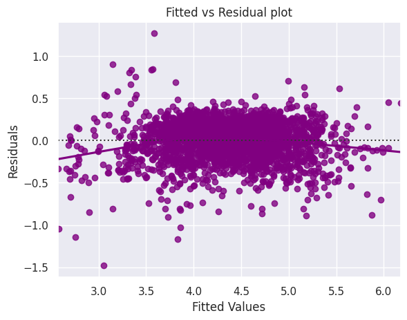

```python
# let's plot the fitted values vs residuals

sns.residplot(
    data=df_pred, x="Fitted Values", y="Residuals", color="purple", lowess=True
)
plt.xlabel("Fitted Values")
plt.ylabel("Residuals")
plt.title("Fitted vs Residual plot")
plt.show()
```

- The scatter plot shows the distribution of residuals (errors) vs fitted values (predicted values).
- If there exist any pattern in this plot, we consider it as signs of non-linearity in the data and a pattern means that the model doesn't capture non-linear effects.
- **We see no pattern in the plot above. Hence, the assumptions of linearity and independence are satisfied.**

### TEST FOR NORMALITY

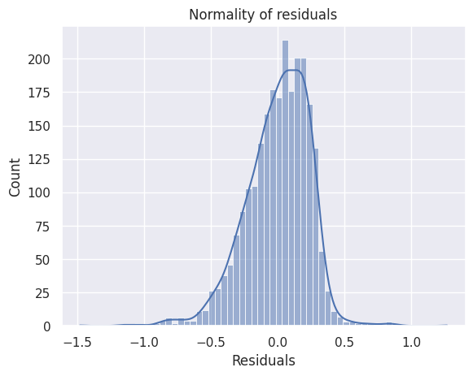

```python
#visualizing the histogram to check the normality
sns.histplot(data=df_pred, x="Residuals", kde=True)
plt.title("Normality of residuals")
plt.show()
```

- The histogram of residuals does have a bell shape.
- Let's check the Q-Q plot.

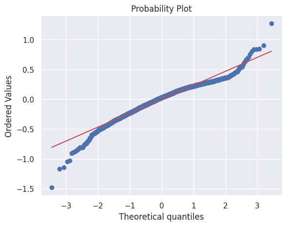

```python
#importing pylab and stats to check normality
import pylab
import scipy.stats as stats

#visuallyising the QQ plot
stats.probplot(df_pred["Residuals"], dist="norm", plot=pylab)
plt.show()
```

- The residuals more or less follow a straight line except for the tails.
- Let's check the results of the Shapiro-Wilk test.

```python
#checking the normality by shapiro test
stats.shapiro(df_pred["Residuals"])
```

```
ShapiroResult(statistic=0.964414119720459, pvalue=6.341512005400132e-24)
```

- Since p-value < 0.05, the residuals are not normal as per the Shapiro-Wilk test.
- Strictly speaking, the residuals are not normal.
- However, as an approximation, we can accept this distribution as close to being normal.
- **So, the assumption is satisfied.**

### TEST FOR HOMOSCEDASTICITY

```python
#import 1zip to check homoscedasticity
from statsmodels.compat import lzip

name = ["F statistic", "p-value"]
test = sms.het_goldfeldquandt(df_pred["Residuals"], x_train3)
lzip(name, test)
```

```
[('F statistic', 1.0773449368825052), ('p-value', 0.09928356428767)]
```

**Since p-value > 0.05, we can say that the residuals are homoscedastic. So, this assumption is satisfied.**

## Predictions on test data

```python
# predictions on the test set
pred = olsmod2.predict(x_test3)

#creating the dataframe with actual and predicted
df_pred_test = pd.DataFrame({"Actual": y_test, "Predicted": pred})
df_pred_test.sample(10, random_state=1)
```

|  | Actual | Predicted |
| --- | --- | --- |
| 2284 | 4.033887 | 4.076390 |
| 3024 | 3.653770 | 3.949736 |
| 527 | 4.536249 | 4.771575 |
| 1688 | 4.474492 | 4.401173 |
| 784 | 4.252203 | 4.362762 |
| 2987 | 3.958907 | 4.070450 |
| 761 | 4.529476 | 4.660106 |
| 3432 | 5.069219 | 4.919852 |
| 2751 | 4.566117 | 4.343849 |
| 3353 | 5.327536 | 5.347499 |

- We can observe here that our model has returned pretty good prediction results, and the actual and predicted values are comparable

## Final Model

```python
# copying the x_train3,x_test3 into x_train,x_test final
x_train_final = x_train3.copy()
x_test_final = x_test3.copy()
```

```python
#this is final model
olsmodel_final = sm.OLS(y_train, x_train_final).fit()
print(olsmodel_final.summary())
```

```
                              OLS Regression Results
=================================================================================
Dep. Variable:     normalized_used_price   R-squared:                       0.840
Model:                               OLS   Adj. R-squared:                  0.840
Method:                    Least Squares   F-statistic:                     1051.
Date:                   Wed, 31 Jan 2024   Prob (F-statistic):               0.00
Time:                           17:17:46   Log-Likelihood:                 38.636
No. Observations:                   2410   AIC:                            -51.27
Df Residuals:                       2397   BIC:                             23.96
Df Model:                             12
Covariance Type:               nonrobust
========================================================================================
                           coef    std err          t      P>|t|      [0.025      0.975]
----------------------------------------------------------------------------------------
const                  -59.4554      6.985     -8.511      0.000     -73.153     -45.757
main_camera_mp           0.0214      0.001     14.706      0.000       0.019       0.024
selfie_camera_mp         0.0129      0.001     11.523      0.000       0.011       0.015
ram                      0.0264      0.005      5.168      0.000       0.016       0.036
weight                   0.0017    6.2e-05     26.778      0.000       0.002       0.002
release_year             0.0301      0.003      8.705      0.000       0.023       0.037
normalized_new_price     0.4450      0.011     39.784      0.000       0.423       0.467
brand_name_Sony         -0.0780      0.032     -2.417      0.016      -0.141      -0.015
brand_name_Xiaomi        0.0767      0.026      2.978      0.003       0.026       0.127
os_Others               -0.1399      0.027     -5.144      0.000      -0.193      -0.087
os_iOS                  -0.1184      0.046     -2.598      0.009      -0.208      -0.029
4g_yes                   0.0545      0.015      3.576      0.000       0.025       0.084
5g_yes                  -0.0680      0.030     -2.244      0.025      -0.127      -0.009
==============================================================================
Omnibus:                      271.684   Durbin-Watson:                   1.998
Prob(Omnibus):                  0.000   Jarque-Bera (JB):              627.943
Skew:                          -0.665   Prob(JB):                    4.40e-137
Kurtosis:                       5.118   Cond. No.                     2.91e+06
==============================================================================

Notes:
[1] Standard Errors assume that the covariance matrix of the errors is correctly specified.
[2] The condition number is large, 2.91e+06. This might indicate that there are
strong multicollinearity or other numerical problems.
```

```python
# checking model performance on train set (seen 70% data)
print("Training Performance\n")
olsmodel_final_train_perf = model_performance_regression(
    olsmodel_final, x_train_final, y_train
)
olsmodel_final_train_perf
```

```
Training Performance
```

|  | RMSE | MAE | R-squared | Adj. R-squared | MAPE |
| --- | --- | --- | --- | --- | --- |
| 0 | 0.238123 | 0.184771 | 0.840352 | 0.839486 | 4.473911 |

```python
# checking model performance on test set (seen 30% data)
print("Test Performance\n")
olsmodel_final_test_perf = model_performance_regression(
    olsmodel_final, x_test_final, y_test
)
olsmodel_final_test_perf
```

```
Test Performance
```

|  | RMSE | MAE | R-squared | Adj. R-squared | MAPE |
| --- | --- | --- | --- | --- | --- |
| 0 | 0.232409 | 0.18168 | 0.83645 | 0.834365 | 4.330859 |

## Actionable Insights and Recommendations

**1. Model Performance:**

**Insight:** The model is pretty good at predicting device prices, explaining about 84% of the differences.

**Recommendation:** Keep using the model but check how well it does with new data. Make updates if needed.

**2. Main Camera Quality:**

**Insight:** Phones with better main cameras tend to cost a bit more.

**Recommendation:** Advertise phones with excellent main cameras to attract buyers who care about photo quality.

**3. Selfie Camera Quality:**

**Insight:** Phones with good selfie cameras have higher prices.

**Recommendation:** Promote phones with impressive selfie cameras to appeal to users who love taking selfies.

**4. RAM (Memory):**

**Insight**: Phones with more memory are priced higher.

**Recommendation:** Keep phones with more memory.the better performance and multitasking.

**5. Device Weight:**

**Insight:** Heavier phones are seen as more valuable.

**Recommendation:** Design and market phones to be a bit heavier for a sturdier feel. Tell customers about the premium build.

**6. Release Year:**

**Insight:** Newer phones are valued more.

**Recommendation:** Keep releasing new models to stay up-to-date with technology trends.

**7. Normalized New Price:**

**Insight:** Higher starting prices are linked to higher used phone prices.

**Recommendation:** Price phones according to their features, and justify higher prices with better specs.

**8. Brand Influence:**

**Insight:** Sony has a negative impact, while Xiaomi has a positive impact on prices.

**Recommendation:** Highlight positive aspects of Xiaomi in marketing.

**9. Operating System Impact:**

**Insight:** Phones with "Others" or "iOS" have a negative impact.

**Recommendation:** Keep an eye on how the operating system affects prices. Adjust marketing if needed.

**10. Connectivity (4G and 5G):**

**Insight:** 4G is good for prices, but 5G isn't.

**Recommendation:** Promote 4G phones. Be careful about promoting 5G unless there's a strong demand for it.